# DATA_621_Blog_1

Euclid Zhang

4/4/2022

# Linear Regression

Linear Regression is a method of modeling the linear relationship between a single numeric variable (called the response variable) and one or more numeric or categorical variables (called the predictors). For example, you have model the quantity of production (response variable) relates to number of workers hired and the quality of the equipment provided (predictor variables)

A linear model is usually used for one or both of the following:

- Predict the outcomes of the response variable for new observations of the predictor variables.
- Test the strengthness between the response variable and a predictor variable.

# Crop Yield VS Fertilizer

Let’s see a simple example of a real life scenario: What is the effect of using fertilizer to the yield of cereals?

The data used is from https://www.kaggle.com/datasets/kkhandekar/any-effect-of-fertilizer-pesticide-on-cereals?select=CerealCropYield_1961-2018.csv

The data is **observational**, not experimental. We would use it to check the relationship between the two variables, **no casual effect**.

The CerealCropYield_1961-2018 file contains the yield of cereals in **Hectogram per Hectare** and the area harvested in **Hectare** of several counties from 1961 to 2018

```r
summary(CerealCropYield)
```

```
##    Country          Yield..hg.ha.     Area.harvested..ha.
##  Length:202         Min.   :  43945   Min.   :2.340e+02
##  Class :character   1st Qu.: 624933   1st Qu.:4.732e+06
##  Mode  :character   Median : 993042   Median :3.032e+07
##                     Mean   :1238853   Mean   :2.667e+08
##                     3rd Qu.:1643923   3rd Qu.:1.343e+08
##                     Max.   :5351936   Max.   :7.503e+09
```

FertilizerConsumption contains the quantity of fertilizer used for several counties from 1961 to 2018

```r
summary(FertilizerConsumption)
```

```
##    Country          FertilizerQuantity
##  Length:184         Min.   :6.312e+03
##  Class :character   1st Qu.:9.429e+05
##  Mode  :character   Median :5.654e+06
##                     Mean   :6.434e+07
##                     3rd Qu.:2.649e+07
##                     Max.   :2.430e+09
```

We first combine the two files and calculate the quantity of fertilizer per **Hectare**

```r
df <- merge(CerealCropYield, FertilizerConsumption, all=FALSE)
```

```r
df$fertilizer_per_ha <- df$FertilizerQuantity / df$Area.harvested..ha.
names(df)[2] <- "yield_per_ha"
df$FertilizerQuantity <- NULL
df$Area.harvested..ha. <- NULL
```

The following is the data ready to build our linear model

```r
summary(df)
```

```
##    Country           yield_per_ha     fertilizer_per_ha
##  Length:178         Min.   :  43945   Min.   :  0.00309
##  Class :character   1st Qu.: 636994   1st Qu.:  0.05928
##  Mode  :character   Median :1034802   Median :  0.24023
##                     Mean   :1245368   Mean   :  2.98516
##                     3rd Qu.:1649640   3rd Qu.:  0.62001
##                     Max.   :5351936   Max.   :171.54643
```

Before building our model, let’s take a look at the distributions of our data

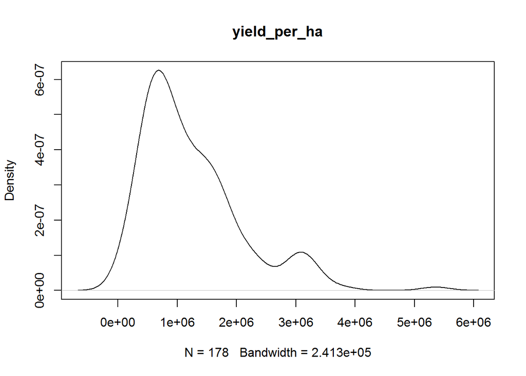

```r
plot(density(df$yield_per_ha), main="yield_per_ha")
```

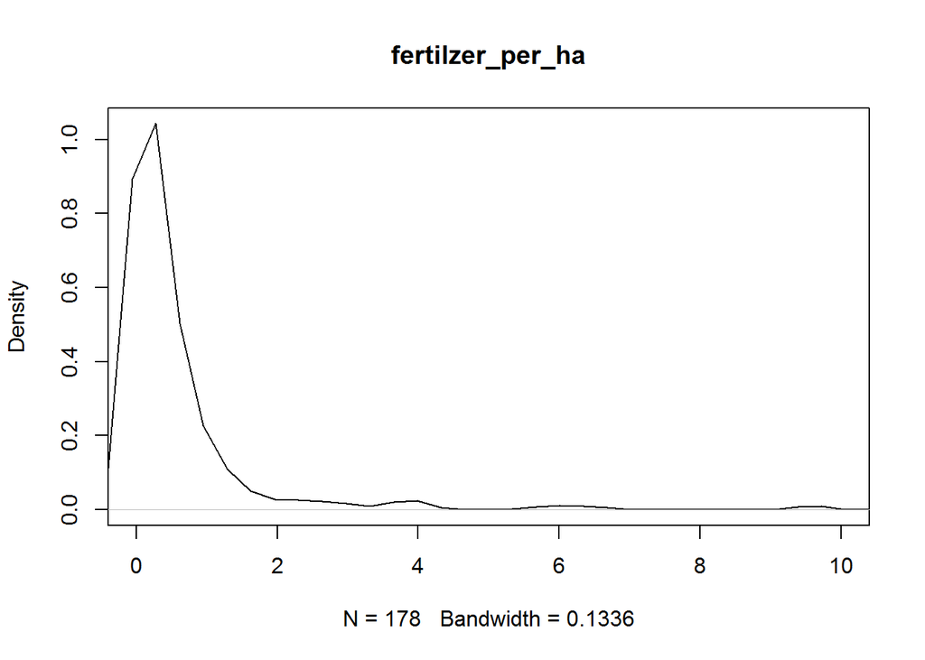

```r
plot(density(df$fertilizer_per_ha), main="fertilzer_per_ha",xlim=c(0,10))
```

Both variables are extremely right skewed. We will log-transform the two variables to reduce outliers.

Next, we will fit the data into a linear model

```r
lm_model <- lm(log(df$yield_per_ha)~log(df$fertilizer_per_ha))
summary(lm_model)
```

```
##
## Call:
## lm(formula = log(df$yield_per_ha) ~ log(df$fertilizer_per_ha))
##
## Residuals:
##      Min       1Q   Median       3Q      Max
## -3.01475 -0.31313  0.07122  0.45663  1.07103
##
## Coefficients:
##                           Estimate Std. Error t value Pr(>|t|)
## (Intercept)               14.06193    0.06575 213.885  < 2e-16 ***
## log(df$fertilizer_per_ha)  0.17831    0.02794   6.382  1.5e-09 ***
## ---
## Signif. codes:  0 '***' 0.001 '**' 0.01 '*' 0.05 '.' 0.1 ' ' 1
##
## Residual standard error: 0.6759 on 176 degrees of freedom
## Multiple R-squared:  0.1879, Adjusted R-squared:  0.1833
## F-statistic: 40.73 on 1 and 176 DF,  p-value: 1.5e-09
```

We can plot the data and the fitted line from out model to see how well it fits

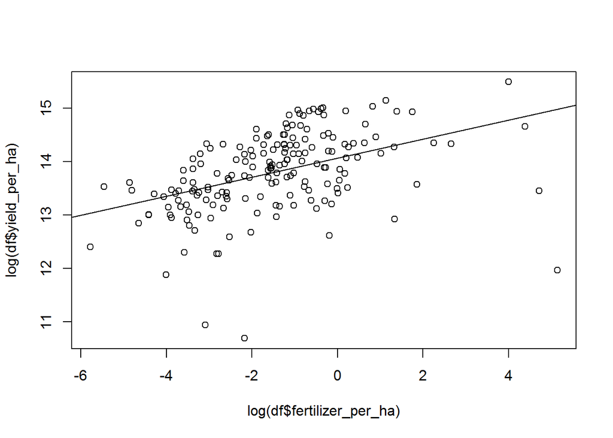

```r
plot(log(df$yield_per_ha)~log(df$fertilizer_per_ha))
abline(lm_model)
```

The relationship seems to be linear and there are some outliers in the data (the points far way from the model line)

Linear Regressions are based on some assumptions. We can perform a diagnosis by plotting the residuals (distance between the model line and actual data point) to see if the the model is valid.

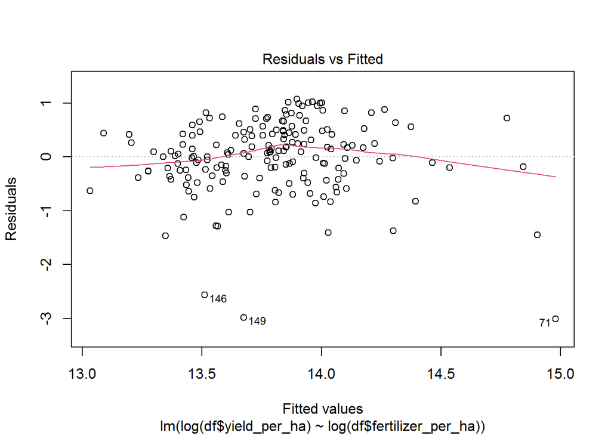

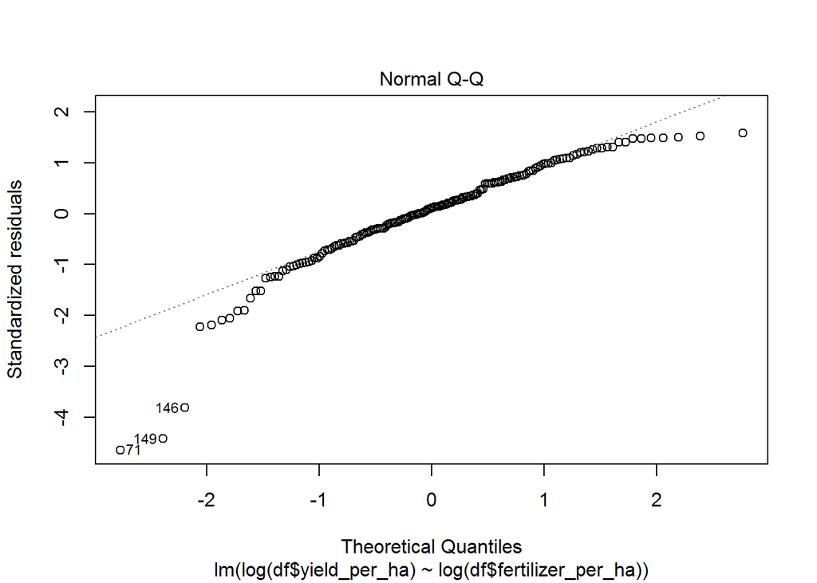

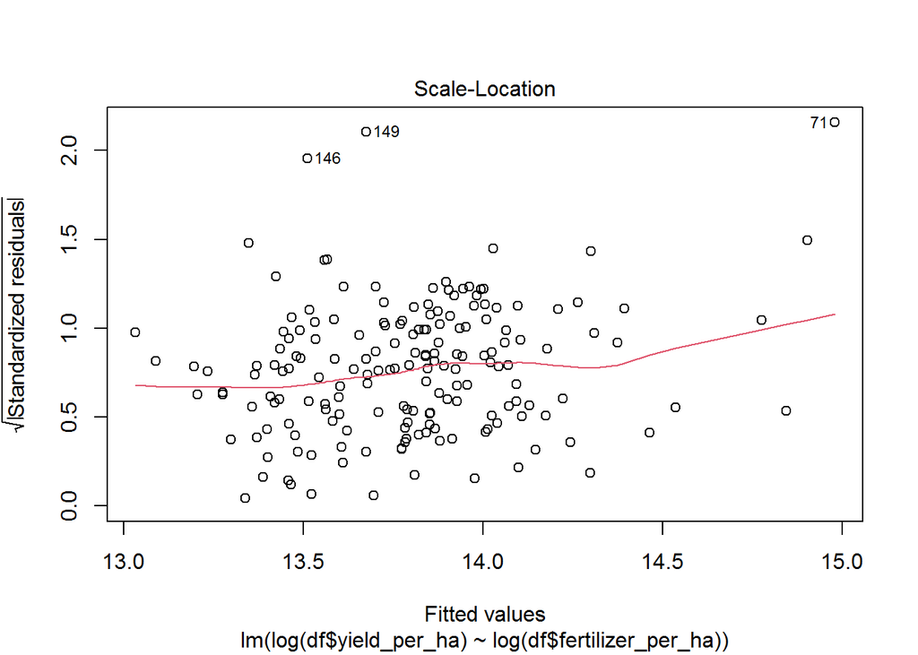

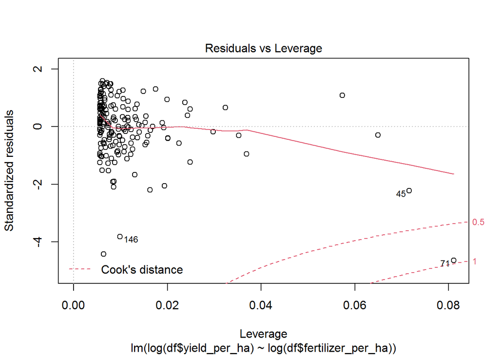

```r
plot(lm_model)
```

1. The relationship between the response variable and each predictor variable is linear: From the Residuals vs Fitted plot, we see that the relationship is approximately linear
2. The variance of residual is Constant: From the Scale-Location plot, the variance is mostly constant except where there are a few outliers
3. The residuals are independent: From the Residuals vs Fitted plot, the residuals are constant
4. The residuals of the model are normally distributed: From the Normal Q-Q plot, most of the residuals are normally distributed, except some outliers.

In summary, our model doesn’t have any serious problems except there are a few extrem outliers. We can check the outliers indicated in the plots

```r
df[c(45,71,146,149),]
```

```
##         Country yield_per_ha fertilizer_per_ha
## 45     Djibouti       694422      111.51282051
## 71      Iceland       157090      171.54643293
## 146 South Sudan        56589        0.04565901
## 149       Sudan        43945        0.11409316
```

They are the case with nearly 0 fertilizer or extremely high usage of fertilizers. Practically this shouldn’t be done. Hence, we will remove these outliers and rebuild our model

```r
df2 <- df
df2 <- df2[c(-45,-71,-146,-149),]
```

```r
lm_model <- lm(log(df2$yield_per_ha)~log(df2$fertilizer_per_ha))
```

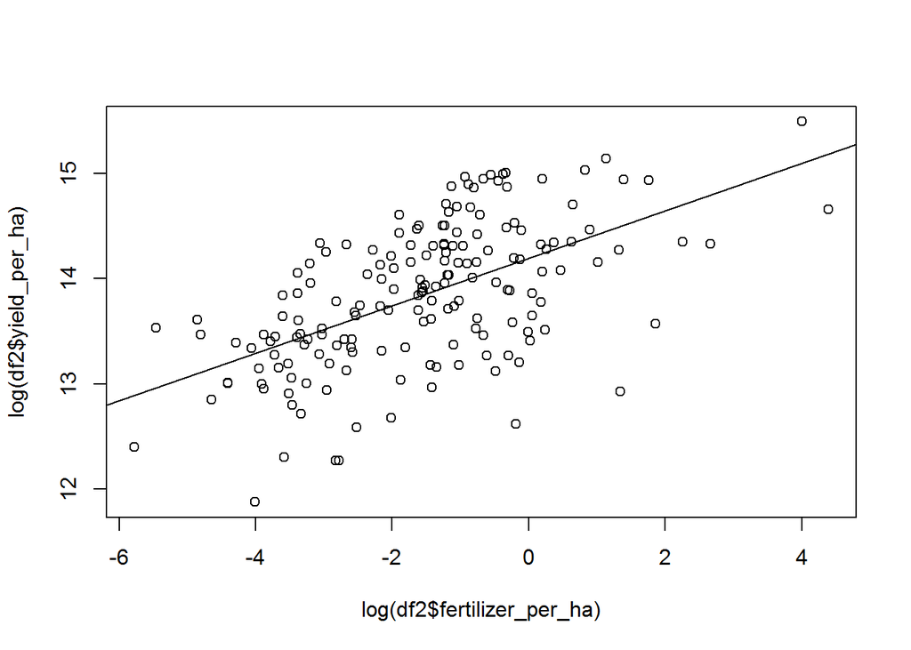

```r
plot(log(df2$yield_per_ha)~log(df2$fertilizer_per_ha))
abline(lm_model)
```

The revised model looks a lot better.

# Conclusion

Now, let’s see what our model tells us.

```r
summary(lm_model)
```

```
##
## Call:
## lm(formula = log(df2$yield_per_ha) ~ log(df2$fertilizer_per_ha))
##
## Residuals:
##      Min       1Q   Median       3Q      Max
## -1.57044 -0.33808  0.03718  0.39664  0.98353
##
## Coefficients:
##                            Estimate Std. Error t value Pr(>|t|)
## (Intercept)                14.19331    0.05670 250.330   <2e-16 ***
## log(df2$fertilizer_per_ha)  0.22560    0.02462   9.162   <2e-16 ***
## ---
## Signif. codes:  0 '***' 0.001 '**' 0.01 '*' 0.05 '.' 0.1 ' ' 1
##
## Residual standard error: 0.5499 on 172 degrees of freedom
## Multiple R-squared:  0.328,  Adjusted R-squared:  0.3241
## F-statistic: 83.95 on 1 and 172 DF,  p-value: < 2.2e-16
```

The t-value, or Pr(>|t|) tells us that the coefficient for the log-transformed fertilizer_per_ha is nearly impossible to be 0. This indicates a strong relationship between the corp yield and the quantity of fertilizer used. Since both the response variable and the predictor variable are log-transformed, we can interpret the coefficient as “a percentage increase in the quantity of the fertilizer increase the corp yield by approximately 0.2256 percent”.

Recall that this is observation data, not experimental data. The model proves the relationship between the two variables, not the casual effect. To confirm if there is a casual effect, data from experiments should be collected.